# Assignment 2

1. Show the percentage of transactions (by numbers) by days of the week (extra 1% of total points)

```r
# Getting the total no.of day transactions and its percentage

Day_Percent <- OnlineRetail %>% group_by(Invoice_Day_Week) %>% summarise(Trans_Number= n(), Percent= sum(n()/length(OnlineRetail$Invoice_Day_Week)*100))
```

```r
#Show the dataframe

as.data.frame(Day_Percent)
```

```
##   Invoice_Day_Week Trans_Number  Percent
## 1           Friday        82193 15.16731
## 2           Monday        95111 17.55110
## 3           Sunday        64375 11.87930
## 4         Thursday       103857 19.16503
## 5          Tuesday       101808 18.78692
## 6        Wednesday        94565 17.45035
```

2. Show the percentage of transactions (by transaction volume) by days of the week (extra 1% of total points)

```r
# Getting the total volume of transactions by week and it's percentage

Totalday_percent <- OnlineRetail%>% group_by(Invoice_Day_Week)%>% summarise(Total_trans= sum(TransactionValue))%>% mutate(Percent= Total_trans/sum(Total_trans)*100)
```

```r
as.data.frame(Totalday_percent)
```

```
##   Invoice_Day_Week Total_trans   Percent
## 1           Friday   1540610.8 15.804787
## 2           Monday   1588609.4 16.297194
## 3           Sunday    805678.9  8.265282
## 4         Thursday   2112519.0 21.671867
## 5          Tuesday   1966182.8 20.170636
## 6        Wednesday   1734147.0 17.790232
```

3. Show the percentage of transactions (by transaction volume) by month of the year (extra 2% of total points)

```r
# Getting total transaction value by months and it's percent

Totalmonth_percent <- OnlineRetail%>% group_by(New_Invoice_Month)%>% summarise(Total_trans= sum(TransactionValue))%>% mutate(Percent= Total_trans/sum(Total_trans)*100)
```

```r
as.data.frame((Totalmonth_percent))
```

```
##    New_Invoice_Month Total_trans   Percent
## 1                  1    560000.3  5.744919
## 2                  2    498062.6  5.109515
## 3                  3    683267.1  7.009487
## 4                  4    493207.1  5.059703
## 5                  5    723333.5  7.420519
## 6                  6    691123.1  7.090080
## 7                  7    681300.1  6.989308
## 8                  8    682680.5  7.003469
## 9                  9   1019687.6 10.460751
## 10                10   1070704.7 10.984123
## 11                11   1461756.2 14.995836
## 12                12   1182625.0 12.132290
```

4. What was the date with the highest number of transactions from Australia? (extra 2% of total points)

```r
# Selecting the date with highest number of transactions from Australia

Highest_num<- OnlineRetail%>% filter(OnlineRetail$Country == "Australia")%>% group_by(New_Invoice_Date)%>% summarise(Aus_TransactionValue= n())%>% top_n(1, Aus_TransactionValue)
```

```r
as.data.frame(Highest_num)
```

```
##   New_Invoice_Date Aus_TransactionValue
## 1       2011-06-15                  139
```

On 2011-06-15 Australia recorded the highest number of transactions i.e., 139.

5. The company needs to shut down the website for two consecutive hours for maintenance. What would be the hour of the day to start this so that the distribution is at minimum for the customers? The responsible IT team is available from 7:00 to 20:00 every day.

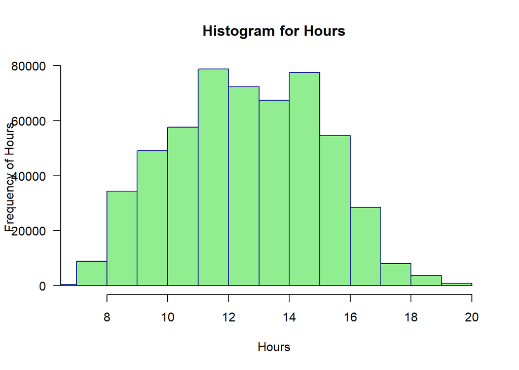

```r
# Histogram for hours

hist(OnlineRetail$New_Invoice_Hour, main= "Histogram for Hours",xlab= "Hours", ylab= "Frequency of Hours",border= "Dark blue",col= "Light green", las=1, xlim=c(7,20), breaks= 12)
```

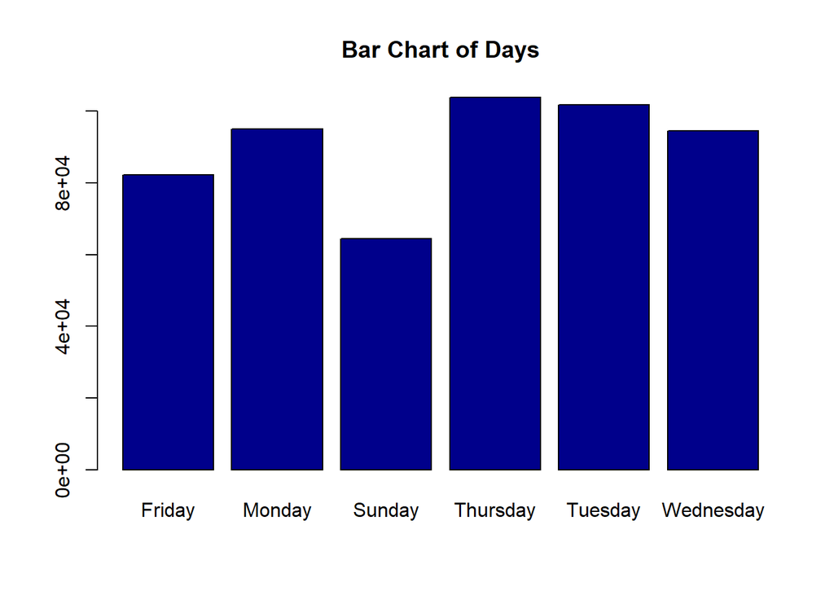

```r
# Bar Chart to identify

barplot(table(OnlineRetail$Invoice_Day_Week), main="Bar Chart of Days",col=" Dark Blue")
```

From the Histogram and the Bar chart we can interpret that the best hours to do the maintenance of the company’s website are between 18:00- 20:00. Moreover, Sunday would be the great day to do the maintenance.

5. Plot the histogram of transaction values from Germany. Use the hist() function to plot.

```r
# Getting the transaction values from Germany

Germany <- select(OnlineRetail,TransactionValue, Country)%>% filter(OnlineRetail$Country == "Germany")
```

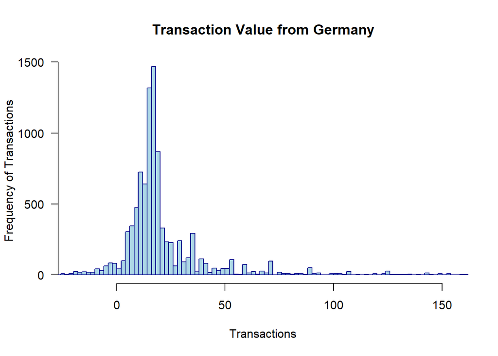

```r
# Histogram for transaction values from Germany

hist(Germany$TransactionValue,xlab= "Transactions",ylab= "Frequency of Transactions",xlim=c(-20,155),las=1, breaks= 600,col= "light blue",border="dark blue", main="Transaction Value from Germany")
```

6. Which customer had the highest number of transactions? Which customer is most valuable (i.e. highest total sum of transactions)?

```r
# Customer with the highest number of transactions

Valuable_customer <- OnlineRetail %>% na.omit()%>% group_by(CustomerID)%>% summarise(Num_highest = n())%>% top_n(1,Num_highest)
```

```r
as.data.frame(Valuable_customer)
```

```
##   CustomerID Num_highest
## 1      17841        7983
```

The customer with CustomerID 17841 had the highest number of transactions amongst the others with a total of 7983.

```r
# Valuable customer with the highest Volume of transactions

Valuable_customer <- OnlineRetail%>% na.omit()%>% group_by(CustomerID)%>% summarise(High_transaction= sum(TransactionValue))%>% top_n(1,High_transaction)
```

```r
as.data.frame(Valuable_customer)
```

```
##   CustomerID High_transaction
## 1      14646           279489
```

The customer with CustomerID 14646 is the valuable customer with the highest transaction sum of 279489 British Sterling Pound.

7. Calculate the percentage of missing values for each variable in the dataset. Hint colMeans():

```r
percent_missing <- colMeans(is.na(OnlineRetail))
```

```r
as.data.frame(percent_missing)
```

```
##                   percent_missing
## InvoiceNo               0.0000000
## StockCode               0.0000000
## Description             0.0000000
## Quantity                0.0000000
## InvoiceDate             0.0000000
## UnitPrice               0.0000000
## CustomerID              0.2492669
## Country                 0.0000000
## TransactionValue        0.0000000
## New_Invoice_Date        0.0000000
## Invoice_Day_Week        0.0000000
## New_Invoice_Hour        0.0000000
## New_Invoice_Month       0.0000000
```

Out of all the Variables in the dataset CustomerID is the only attribute with 24.92669% of NAs.

8. What are the number of transactions with missing CustomerID records by countries?

```r
 # Number of Transactions with missing CustomerID records by countries

ID_missing<- OnlineRetail%>% group_by(Country, CustomerID)%>% filter(is.na(CustomerID)) %>% summarise(Num_trans= n())
as.data.frame(ID_missing)
```

```
##          Country CustomerID Num_trans
## 1        Bahrain         NA         2
## 2           EIRE         NA       711
## 3         France         NA        66
## 4      Hong Kong         NA       288
## 5         Israel         NA        47
## 6       Portugal         NA        39
## 7    Switzerland         NA       125
## 8 United Kingdom         NA    133600
## 9    Unspecified         NA       202
```

There are 9 countries with missing CustomerID records, out of which the United Kingdom is the highest with 133600 missing values.

9. On average, how often the costumers comeback to the website for their next shopping? (i.e. what is the average number of days between consecutive shopping)

```r
# Days average between consecutive shopping

Days_Avg <- OnlineRetail %>% select(CustomerID, New_Invoice_Date) %>% group_by(CustomerID) %>% mutate(Days_diff = as.numeric(c(diff(New_Invoice_Date),0))) %>% summarise(Days_time = sum(Days_diff),
Days_Avg = sum(Days_diff)/sum(n()))
```

```r
head(as.data.frame(Days_Avg))
```

```
##   CustomerID Days_time Days_Avg
## 1      12346         0 0.000000
## 2      12347       365 2.005495
## 3      12348       283 9.129032
## 4      12349         0 0.000000
## 5      12350         0 0.000000
## 6      12352       260 2.736842
```

10. In the retail sector, it is very important to understand the return rate of the goods purchased by customers. In this example, we can define this quantity, simply, as the ratio of the number of transactions cancelled (regardless of the transaction value) over the total number of transactions. With this definition, what is the return rate for the French customers? Consider the cancelled transactions as those where the ‘Quantity’ variable has a negative value.

```r
# Return rate for the French customers

numerator <- OnlineRetail %>% select(Quantity, TransactionValue, Country) %>% filter(Country == "France" & Quantity < 0)
denominator <- OnlineRetail %>% select(Quantity, TransactionValue, Country) %>% filter(Country == "France")
Ratio <- count(numerator) / count(denominator)


as.data.frame(Ratio)
```

```
##            n
## 1 0.01741264
```

The return rate for the French customers is 1.741264%

11. What is the product that has generated the highest revenue for the retailer? (i.e. item with the highest total sum of ‘TransactionValue’).

```r
# Highest revenue for the retailer

Rev_Highest <- OnlineRetail %>% group_by(Description) %>%
summarise(Trans_highest = sum(TransactionValue)) %>%
  top_n(1)
as.data.frame((Rev_Highest))
```

```
##      Description Trans_highest
## 1 DOTCOM POSTAGE      206245.5
```

The product generating the highest revenue for the retailer is DOTCOM POSTAGE i.e., 206245.5 British Sterling Pound.

12. How many unique customers are represented in the dataset? You can use unique() and length() functions.

```r
#Showing the number of unique customers

length(unique(OnlineRetail$CustomerID))
```

```
## [1] 4373
```

There are total of 4373 unique customers